# Trusting the Process

Wednesday, April 3rd, 2019

## Amplify

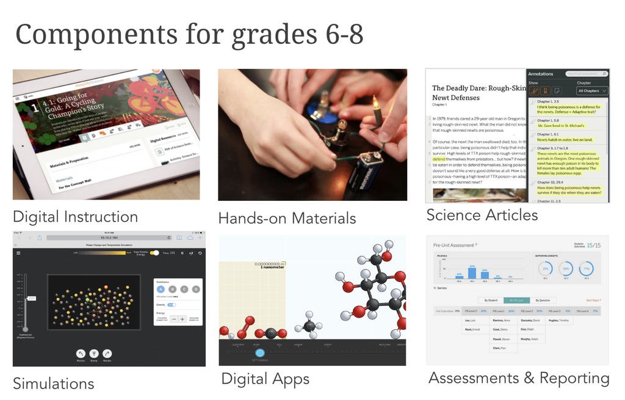

## Workflow

What is workflow?

- Your personal way of taking data and turning it into product
- Eg your software, home directory name, and your unpolished work

What is product?

- Your raw data
- All code that is run to clean and use your raw data

## Why care about your workflow?

- Collaboration
- Self-care
- Reproducibility
- Environment switching

## How?

- Clear file structure
- Software that allows for all your needs (in my case R and RStudio with R Projects, R Markdown, and a connection to a redshift DB)

## File structure

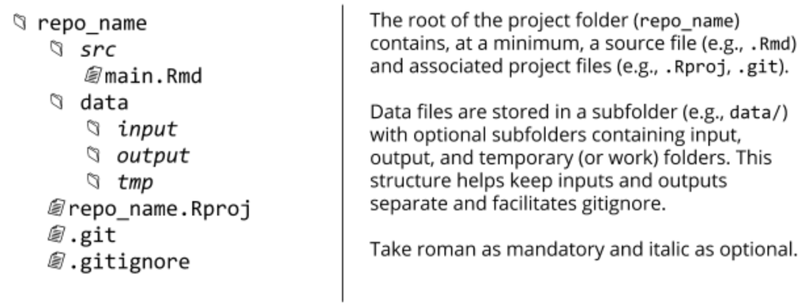

- To maximize reproducibility projects files should be git repositories and structured in a logical, consistent manner
- Use RStudio git GUI or in the Terminal tab in RStudio
- [Useful git in RStudio resource](https://rpubs.com/adam_dennett/430188)

## File Structure

File creation shortcut

```r
library(here)

folder_names <- c("src", "input_data", "output_data")  # set folder names
sapply(folder_names, dir.create)  # generate folders in current directory
```

Example project folder

[figure not shown]

## Use R projects

[figure not shown]

[figure not shown]

- Run multiple projects!
- Keep all your work contained together in one area
- Share work and collaborate easily

## Use here::here()

- DO NOT USE setwd()
- It won’t work for others and it probably won’t work for you in a year either
- Instead, use the here package

```r
library(here)

here()
```

```
## [1] "/Users/ljanda/Documents/misc/tdp_workflow_talk"
```

```r
ul <- read_csv(here::here("data/input/unit_lookup_table.csv"))
```

## Never save workspace

- All R scripts should be written with the ability to run from a fresh R instance on any computer

[figure not shown]

## Other tips

- Leave your .Rprofile alone!
- Restart R often, re-run code in a fresh setting
- This does not mean that your code has to look beautiful and perfect! Just that it can run without being dependent on anything that you set locally
- But, do follow a code style guide so that it is easy to read
- [RStudio style guide](http://adv-r.had.co.nz/Style.html)
- [google style guide](https://google.github.io/styleguide/Rguide.xml)
- [Can use styler package to restyle code](https://github.com/r-lib/styler)

## Database Connection

- If you can connect directly to a DB, do it!
- Then your source code is the important material, not the CSV sitting somewhere
- If the query is large, can always write it to a file like .csv, .Rda, .feather, etc then read that in for any report

## DB Connection

- Can use SQL

```r
t1 <- tbl(con, sql(
  "SELECT
    dim_user.user_business_key AS user_business_key,
  dim_user.school_name AS school_name,
  TO_CHAR(fact_curriculum_event.request_time,
    'YYYY-MM-DD HH24:MI:SS.MS') AS timestamp_date_time,
    fact_curriculum_event.body_object_id AS event_name
  FROM events.events_curriculum AS fact_event
  LEFT JOIN users.dim_user AS dim_user
  ON fact_curriculum_event.body_actor_account_name =
      dim_user_v2.user_business_key
  WHERE (dim_user.district_name = 'District1')"))
```

## DB Connection

- Can also use dplyr code with the dbplyr package

```r
t2 <-
  t1 %>%
  filter(school_name == "School One") %>%
  collect()

BRRR::skrrrahh(sound = 26)

path <- here::here("data/raw_events.feather")
write_feather(t1, path)
```

## DB Connection

- Can wrap connection in a function and call the function or make a package

```r
amp_connect <- function(key_name = "datawarehouse") {
 DBI::dbConnect(odbc::odbc(),
            Driver   = "driver/path/libamazonredshiftodbc.dylib",
            Server   = "localhost",
            Port     = 5439,
            Database = "dev",
            UID      = keyring::key_list("datawarehouse")[1,2],
            PWD      = keyring::key_get("datawarehouse"),
            bigint   = "integer")
}
```

## Reports

- Making reports like RMarkdown look nice, are easy to share
- Can be knit to doc and shared as a google doc for collaborative editing with coworkers that don’t code
- Can be knit to html and hosted to share easily when editing is not needed
- Use kable and kableExtra, tabset, html, and css to make them extra nice

## Parameterized YAML headers

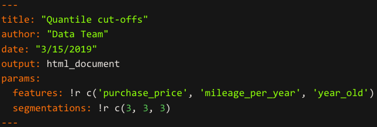

- [Parameterized Yaml Headers](https://r4ds.had.co.nz/r-markdown.html#yaml-header)

## Summary

- Source is product
- Don’t do anything locally, do it all in your code!
- Use rprojects, here(), DB connection, git, rmarkdown

[figure not shown]

## Thank you!

- Szu-Min for inviting me
- My team at Amplify (Samuel Crane, Harry Gamble, Tashi Lama)
- Sebastian Teran Hidalgo

## Resources

- [Workflow blog post from Jenny Bryan](https://www.tidyverse.org/articles/2017/12/workflow-vs-script/)
- [Useful git in RStudio resource](https://rpubs.com/adam_dennett/430188)
- [RStudio style guide](http://adv-r.had.co.nz/Style.html)
- [google style guide](https://google.github.io/styleguide/Rguide.xml)
- [Styler package](https://github.com/r-lib/styler)
- [DB connection webinar](https://www.rstudio.com/resources/videos/best-practices-for-working-with-databases-webinar/)
- [Parameterized Yaml Headers](https://r4ds.had.co.nz/r-markdown.html#yaml-header)